# Exploration

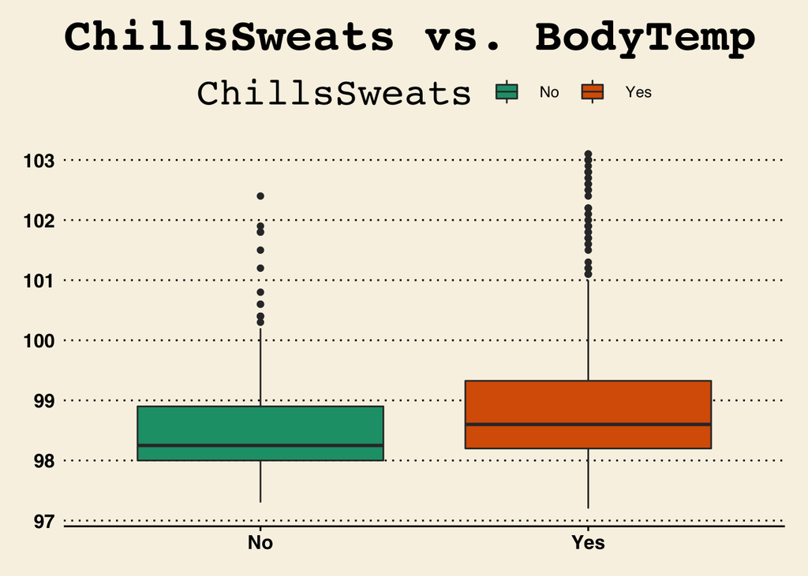

```r
  # ChillSweats
processeddta %>% ggplot( mapping = aes(x = ChillsSweats, y = BodyTemp)) +
  geom_boxplot(aes(fill = ChillsSweats))+
  labs(title= "ChillsSweats vs. BodyTemp") +
  theme_wsj() +
  scale_fill_brewer(palette = "Dark2")
```

Both Fatigue and Chill Sweats seem to follow a similar pattern. May be worth putting in a model.

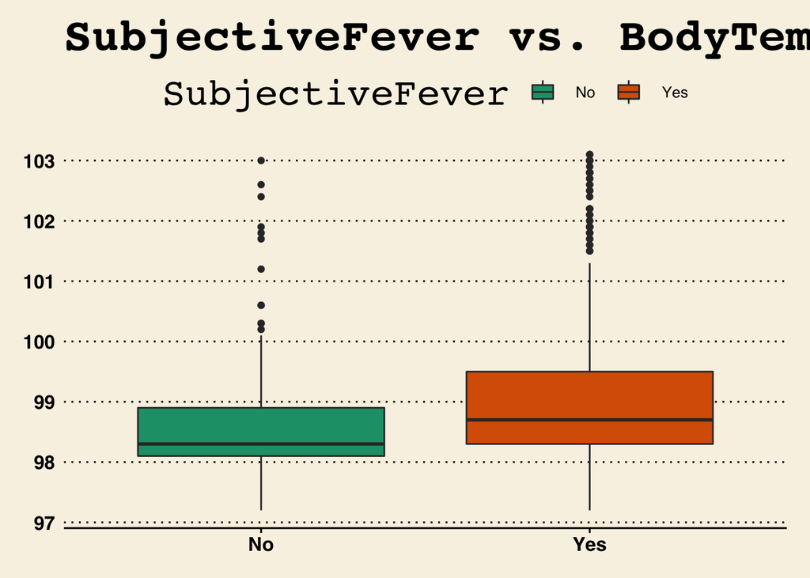

```r
  # SubjectiveFever
processeddta %>% ggplot( mapping = aes(x = SubjectiveFever, y = BodyTemp)) +
  geom_boxplot(aes(fill = SubjectiveFever))+
  labs(title= "SubjectiveFever vs. BodyTemp") +
  theme_wsj() +
  scale_fill_brewer(palette = "Dark2")
```

Subjective fever appears to be an interesting figure as well.

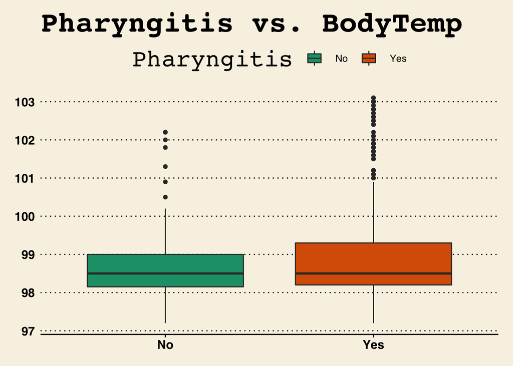

```r
  #Pharyngitis
processeddta %>% ggplot( mapping = aes(x = Pharyngitis, y = BodyTemp)) +
  geom_boxplot(aes(fill = Pharyngitis))+
  labs(title= "Pharyngitis vs. BodyTemp") +
  theme_wsj() +
  scale_fill_brewer(palette = "Dark2")
```

Pharyngitis appears to not have much of a difference. It does however have a lot of outlier temperatures. I would be interested to see how it compares with those who have a fever body temp (>= 100.4)

# Ok lets look temperatures >= 100.4

I will be sticking with same variables used earlier.

```r
# Ok lets look at fever only
feverds <- processeddta[processeddta$BodyTemp >= 100.4, c("Fatigue", "ChillsSweats", "SwollenLymphNodes", "Pharyngitis", "Insomnia", "Headache", "SubjectiveFever", "CoughIntensity", "BodyTemp")]

# Now lets look at some variables versus fever body temperature
feverds %>% tbl_summary() %>%
  modify_caption("**Table 3. Patient Characteristics vs. BodyTemp > 100.4**")
```

**Table 3. Patient Characteristics vs. BodyTemp > 100.4**

| **Characteristic** | **N = 85**<sup>1</sup> |
| --- | --- |
| Fatigue | 81 (95%) |
| ChillsSweats | 73 (86%) |
| SwollenLymphNodes | 34 (40%) |
| Pharyngitis | 78 (92%) |
| Insomnia | 48 (56%) |
| Headache | 72 (85%) |
| SubjectiveFever | 76 (89%) |
| CoughIntensity |  |
| None | 3 (3.5%) |
| Mild | 26 (31%) |
| Moderate | 32 (38%) |
| Severe | 24 (28%) |
| BodyTemp | 101.70 (100.90, 102.50) |

<sup>*1*</sup> n (%); Median (IQR)

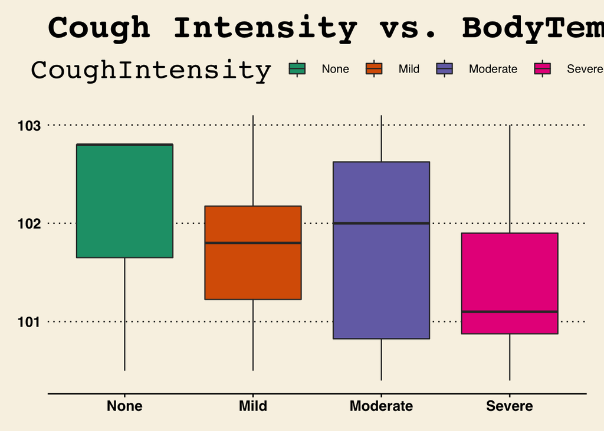

```r
# Cough Intensity
feverds %>% ggplot( mapping = aes(x = CoughIntensity, y = BodyTemp)) +
  geom_boxplot(aes(fill = CoughIntensity))+
  labs(title= "Cough Intensity vs. BodyTemp > 100.4") +
  theme_wsj() +
  scale_fill_brewer(palette = "Dark2")
```

It seems those who reported lack of cough have a higher temperature out of those who have a fever

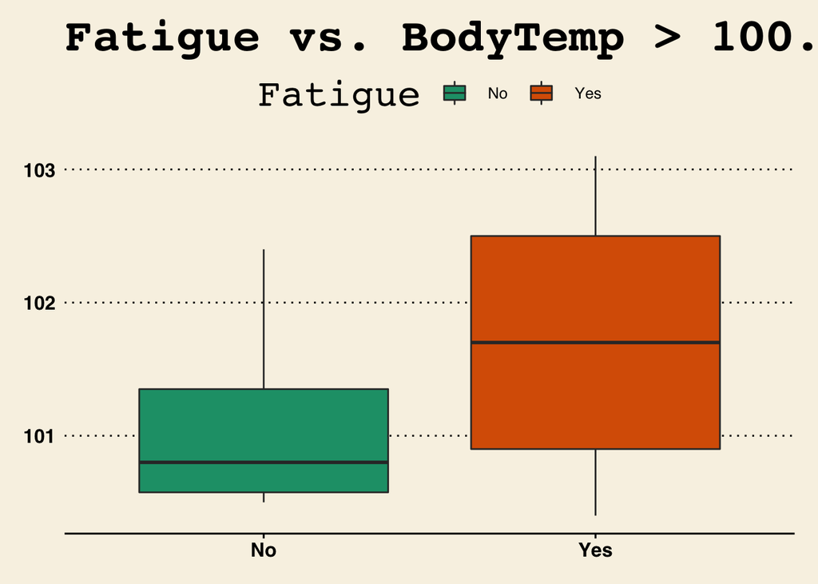

```r
  # Fatigue
feverds %>% ggplot( mapping = aes(x = Fatigue, y = BodyTemp)) +
  geom_boxplot(aes(fill = Fatigue))+
  labs(title= "Fatigue vs. BodyTemp > 100.4") +
  theme_wsj() +
  scale_fill_brewer(palette = "Dark2")
```

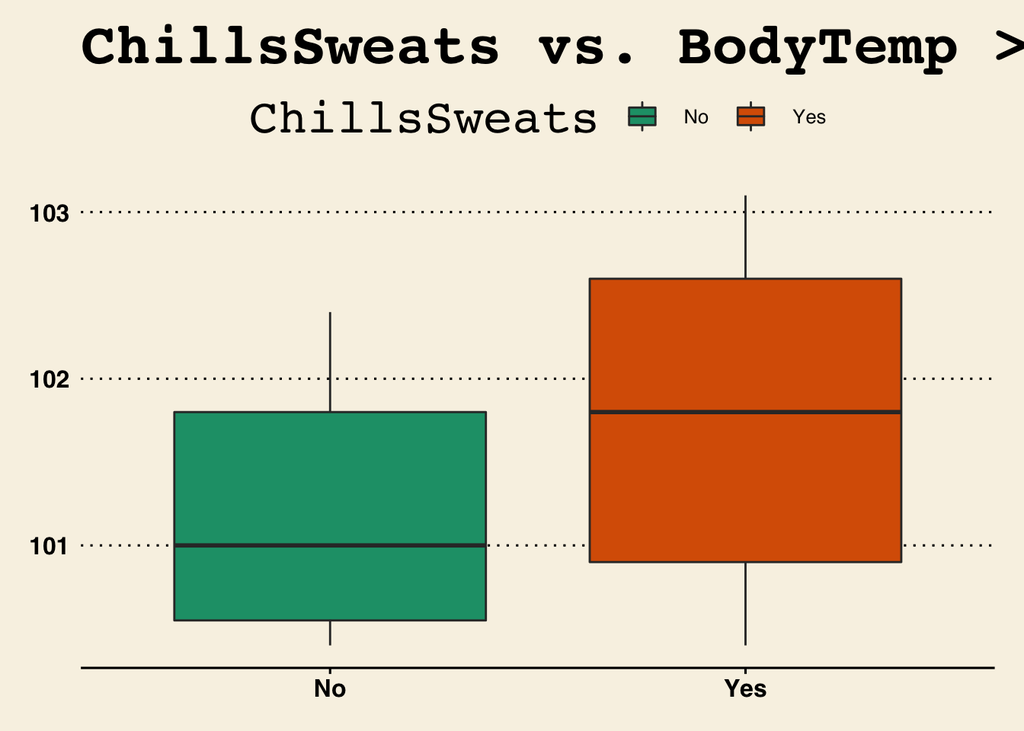

```r
  # ChillSweats
feverds %>% ggplot( mapping = aes(x = ChillsSweats, y = BodyTemp)) +
  geom_boxplot(aes(fill = ChillsSweats))+
  labs(title= "ChillsSweats vs. BodyTemp > 100.4") +
  theme_wsj() +
  scale_fill_brewer(palette = "Dark2")
```

Both Fatigue and Chill Sweats seem to follow a similar pattern.

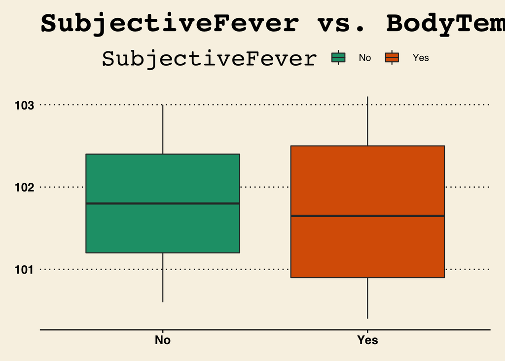

```r
  # SubjectiveFever
feverds %>% ggplot( mapping = aes(x = SubjectiveFever, y = BodyTemp)) +
  geom_boxplot(aes(fill = SubjectiveFever))+
  labs(title= "SubjectiveFever vs. BodyTemp > 100.4") +
  theme_wsj() +
  scale_fill_brewer(palette = "Dark2")
```

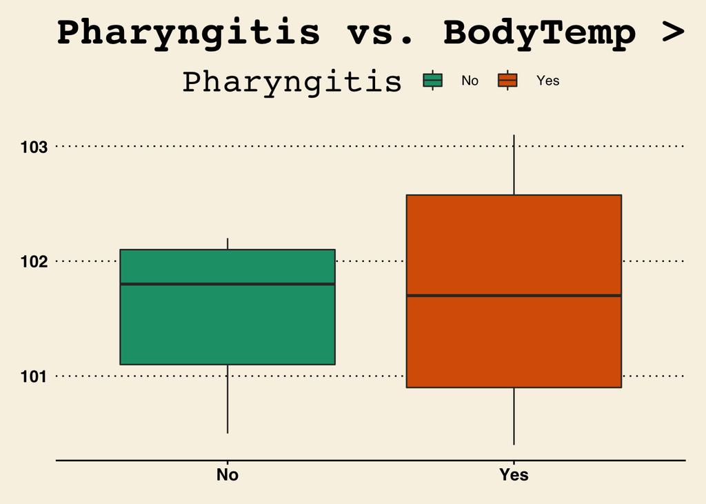

```r
  #Pharyngitis
feverds %>% ggplot( mapping = aes(x = Pharyngitis, y = BodyTemp)) +
  geom_boxplot(aes(fill = Pharyngitis))+
  labs(title= "Pharyngitis vs. BodyTemp > 100.4") +
  theme_wsj() +
  scale_fill_brewer(palette = "Dark2")
```

These two seem to be less likely to have higher temperatures. I would have though that those who reported a fever would be more likely to actually have a higher body temperature

For body temperature and specifically fever, I think Fatigue and Chill Sweats show the strongest association with higher temperature in those who have a temperature > 100.4

# New Data

After looking at all the choosed variables, I will put them into one final dataset before model fitting. As a recap: - Main continuous outcome of interest = Body temperature - Main categorical outcome = Nausea

Other predictor variables - Fatigue (y/n) - CoughIntensity (none/mild/moderate/severe) - ChillsSweats (y/n) - SwollenLymphNodes (y/n) - Pharyngitis (y/n) - Insomnia (y/n) - Headache (y/n) - SubjectiveFever (y/n)

```r
smalldta <- processeddta[, c("Fatigue", "ChillsSweats", "SwollenLymphNodes", "Pharyngitis", "Insomnia", "Headache", "SubjectiveFever", "CoughIntensity", "BodyTemp", "Nausea")]

save_data_location <- here::here("data","processed_data","smalldta.rds")
saveRDS(smalldta, file = save_data_location)

# For fun, I am saving fever DS
save_data_location2 <- here::here("data","processed_data","feverdta.rds")
saveRDS(feverds, file = save_data_location2)
```